# index slides

**More Practical Methods To Reduce Privacy Loss When Disclosing Statistics Based On Microdata**

**0. Abstract** *(:30)*

We replicate a simple method by Chetty and Friedman (2019) to reduce privacy loss when disclosing regression estimates.

The extension of research aims to create a practical method to attain provably Differentially Private regression estimates.

Algorithms we test are as follows:

- Algorithm A: Chetty & Friedman (2019) Algorithm
  - For OLS
  - Modified for ad-hoc MM-Estimation
  - Comparison with Koller & Stahel (2014) "SMDM"-Estimation
- Algortihm B: Dwork & Lei (2009) Algorithm
  - The problem with OLS in DP
  - Comparing ad-hoc MM against SDMD
- Comparison with existing algorithms: *[WIP]*
  - A.Smith's (2011) Widened Winsorized Mean - for large samples
  - B.Rubenstein (2017) The Bernstein mechanism - Melbourne University

**1. The Problem** *(:30)*

U.S. Census Microdata:

- Dinur and Nissim (2003)
  - Database Reconstruction Attack
- Garfinkel et al. (2018); defending against a DRA:
  - Publish less data
  - Apply noise before tabulation
  - Apply noise to the published statistics
- Without a privacy-protection system based on noise injection, it would be feasible to reconstruct accurate microdata using only the published statistics

**2. Diclosure Avoidance Methods** *(1:30)*

**Statatistical Disclosure Limitation (SDL)**

The SDL framework for protecting against identity

Exsting Methods:

- [for] Continuous Variables:
  - Adding Noise
  - Microaggregation
  - Shuffling (data swapping)
- [for] Categorical Variables:
  - Recoding & Local Suppression (omitting data)

**Differential Privacy**

**Definition 1.**

- a randomised function $\mathcal{K}$ gives $(\epsilon,\delta)$-*differential privacy* if for all data sets $D$ and $D'$ differing on at most one element, and all $S\subset \text{Range}\left(\mathcal{K}\right)$;

$$\mathbb{P}\left[\mathcal{K}\left( D \right)\in S\right] \le e^{\epsilon} \cdot \mathbb{P} \left[\mathcal{K}\left( D' \right) \in S \right] + \delta $$

- Differential Privacy compares the risk of an individual/group when included in, versus when not included in, the database.
- privacy comes from uncertainty, and differentially private mechanisms provide that uncertainty by adding an amount of noise
  - similar in spirit to randomized response
- the parameter $\epsilon$ is a policy question; often thought of as $\in(0,1)$

Ultimately we aim to obtain $(\epsilon,\delta)$-*differential privacy* whilst preserving the accuracy and usefulness of the statistic

**3. Challenges** *(:30)*

The key technical challenge is determining the sensitivity of the regression estimates.

**Definition 2.**

For $f:\mathcal{D}\to\mathbb{R}^d$, the *sensitivity* of $f$ is;

$$\Delta f = \max_{D, D'}\lVert f(D) - f(D')\rVert_1$$

The most common approach is to measure the *global* sensitivity of the statistic by computing the maximum amount a regression estimate could change when a single observatiom is added for *any possible realisation of the data*

- The problem however is that for standard regression methods, the sensitivity is infinite

However, one can compute the *local sensitivity* looks at the changes for any given sample.

- The problem however is that releasing the local sensitivity may *itself* divulge private information.

**4. Chetty & Friedman (2019)** *(1:30)*

They compute the local sensitivity in each cell (e.g. each Census tract) and then define the *maximum observed sensitivity* (MOS), adjusting for differences in cell sample sizes

They then add noise proportional to the MOS

**5. Implementation**

With the linear model: $$ Y_{cell} = \textbf{X}_{cell}^T\beta_{cell}+\phi_{cell}$$

[0]

- estimate true statistics for each cell:

[1]

- calculate the local sensivity for each cell by including outlier $d$:

$$ \text{LS}_{cell}=\max_{d\in D'_{cell}}|\hat\beta_{\pm d}-\hat\beta|$$

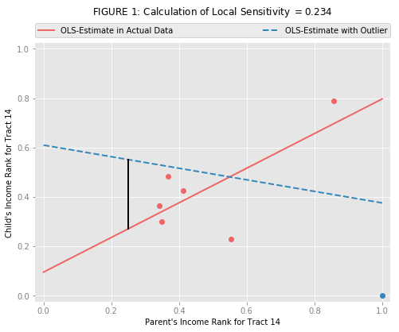

```python
olsf1.plot()
```

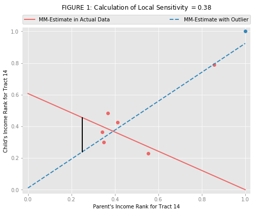

```python
mmf1.plot()
```

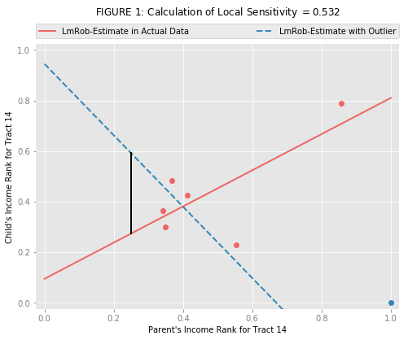

```python
Rf1.plot()
```

[2]

- compute the MOS envelope parameter $\chi$:

$$ \chi = \max_{cell}|\text{N}_{cell} \cdot \text{LS}_{cell}|$$

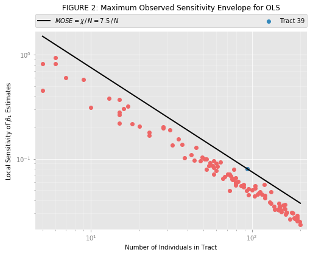

```python
olsf2.plot()
```

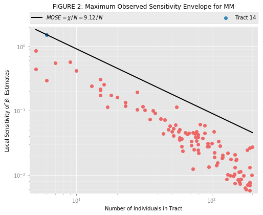

```python
mmf2.plot()
```

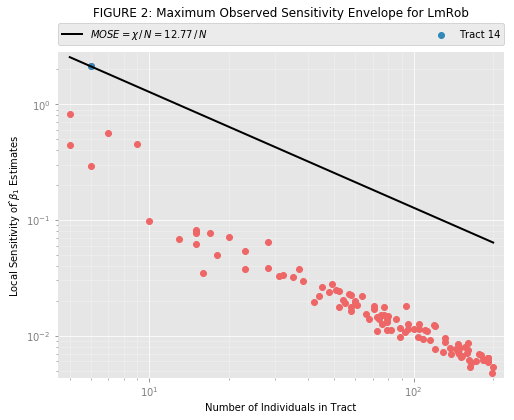

```python
Rf2.plot()
```

[3] - Determine privacy parameter:

- n.b.: Chetty & Freidman use $\epsilon=4$ from comparing $\epsilon\in\{1,2,...,10\}$

[4] - Add random noise, $\omega \sim \text{Laplace}\left(0,\frac{1}{\sqrt{2}}\right)$:

$$ \tilde\beta_{cell} = \beta_{cell} + \sqrt{2}\frac{\chi}{\epsilon\cdot\text{N}_{cell}}\cdot\omega$$

- *repeat 4. for $\text{N}_{cell}$ and $\text{SE}\left(\tilde\beta_{cell}\right)$*

[5] - Release noise-infused statistics for groups of interest publicly

```python
print("Maximum absolute difference between true statistic by method")
print(a)
print(b)
print(c)
```

```
Maximum absolute difference between true statistic by method
OLS-Estimator: 0.24
MM-Estimator: 1.0616
SMDM-Estimator: 0.2673
```